# **Stage 04 — Operational Target Investigation**

## 3.8. Análisis por contrato y contexto — DIR

Además del análisis por año y régimen, se evaluará el target por contrato y por combinaciones de contexto.

Las dimensiones principales serán:

```
    contract
    contract_code
    year + regime
    contract + regime
```

Este análisis permitirá revisar si el target mantiene un comportamiento razonable entre distintos contratos o si aparecen diferencias fuertes asociadas al rolling de contratos.

La idea no es hacer un análisis excesivamente complejo, sino detectar posibles cambios estructurales que puedan afectar la interpretación del target.

### Celda 1 — Configuración del análisis

```python
# Celda 1 — Configuración
# ============================================================

import numpy as np
import pandas as pd
import matplotlib.pyplot as plt

print("Análisis por contrato y contexto - DIR")
print("=" * 80)

# ------------------------------------------------------------
# Asegurar columnas necesarias
# ------------------------------------------------------------

if "year" not in df_targets_dir.columns:
    df_targets_dir["year"] = df_targets_dir.index.year

if "regime_name" not in df_targets_dir.columns:
    REGIME_NAME_BY_ID = {
        0: "Overnight",
        1: "Pre-market",
        2: "Opening",
        3: "Regular",
        4: "Closing",
    }
    df_targets_dir["regime_name"] = df_targets_dir["regime_id"].map(REGIME_NAME_BY_ID)

if "contract" not in df_targets_dir.columns:
    raise KeyError("No existe la columna 'contract' en df_targets_dir.")

# ------------------------------------------------------------
# Crear contract_code como familia del contrato
# ------------------------------------------------------------
# contract      = H20, M20, U20, Z20...
# contract_code = H, M, U, Z
# ------------------------------------------------------------

df_targets_dir["contract_code"] = (
    df_targets_dir["contract"]
    .astype(str)
    .str[0]
)

print("Columna 'contract_code' creada correctamente usando solo la letra del contrato.")

# Targets DIR
dir_target_cols = [
    f"dir_p{p}_h{h}"
    for h in DIR_HORIZONS
    for p in DIR_PERCENTILES
]

# Variante central para gráficos
selected_targets_context = [
    "dir_p50_h30",
    "dir_p50_h60",
    "dir_p50_h90",
]

print(f"Targets DIR a analizar: {len(dir_target_cols)}")
print(f"Targets seleccionados para gráficos: {selected_targets_context}")
print(f"Contratos disponibles: {sorted(df_targets_dir['contract'].dropna().unique().tolist())}")
print(f"Contract codes disponibles: {sorted(df_targets_dir['contract_code'].dropna().unique().tolist())}")
```

```
Análisis por contrato y contexto - DIR
================================================================================
Columna 'contract_code' creada correctamente usando solo la letra del contrato.
Targets DIR a analizar: 9
Targets seleccionados para gráficos: ['dir_p50_h30', 'dir_p50_h60', 'dir_p50_h90']
Contratos disponibles: ['H20', 'H21', 'H22', 'H23', 'H24', 'H25', 'H26', 'M20', 'M21', 'M22', 'M23', 'M24', 'M25', 'M26', 'U20', 'U21', 'U22', 'U23', 'U24', 'U25', 'Z20', 'Z21', 'Z22', 'Z23', 'Z24', 'Z25']
Contract codes disponibles: ['H', 'M', 'U', 'Z']
```

### Celda 2 — Función resumen por contexto

Esta función permite resumir `DIR` por `contract`, `contract_code`, `year + regime` o `contract + regime`.

```python
# Celda 2 — Función de resumen por contexto
# ============================================================

def summarize_dir_by_context(df, target_cols, group_cols):
    """
    Resume distribución de clases y frecuencia operativa de DIR
    para una o más columnas de contexto.

    Ejemplos:
        group_cols = ["contract"]
        group_cols = ["contract_code"]
        group_cols = ["year", "regime_name"]
        group_cols = ["contract", "regime_name"]
    """

    rows = []

    for target_col in target_cols:
        horizon, percentile = parse_dir_target_name(target_col)

        grouped = df.groupby(group_cols, observed=True)

        for group_key, group in grouped:
            if not isinstance(group_key, tuple):
                group_key = (group_key,)

            group_info = dict(zip(group_cols, group_key))

            total_rows = len(group)

            valid_mask = group[target_col].notna()
            valid_values = group.loc[valid_mask, target_col].astype(int)

            valid_rows = valid_mask.sum()
            nan_rows = total_rows - valid_rows

            long_count = (valid_values == 1).sum()
            short_count = (valid_values == -1).sum()
            no_signal_count = (valid_values == 0).sum()

            signal_count = long_count + short_count

            row = {
                "target": target_col,
                "horizon": horizon,
                "percentile": percentile,
                "total_rows": total_rows,
                "valid_rows": valid_rows,
                "nan_rows": nan_rows,
                "long_count": long_count,
                "short_count": short_count,
                "no_signal_count": no_signal_count,
                "signal_count": signal_count,
                "long_ratio": long_count / valid_rows if valid_rows > 0 else np.nan,
                "short_ratio": short_count / valid_rows if valid_rows > 0 else np.nan,
                "no_signal_ratio": no_signal_count / valid_rows if valid_rows > 0 else np.nan,
                "signal_ratio": signal_count / valid_rows if valid_rows > 0 else np.nan,
                "long_share_over_signals": (
                    long_count / signal_count if signal_count > 0 else np.nan
                ),
                "short_share_over_signals": (
                    short_count / signal_count if signal_count > 0 else np.nan
                ),
            }

            row.update(group_info)
            rows.append(row)

    summary = pd.DataFrame(rows)

    sort_cols = group_cols + ["horizon", "percentile"]
    summary = summary.sort_values(sort_cols).reset_index(drop=True)

    return summary


print("Función summarize_dir_by_context lista.")
```

```
Función summarize_dir_by_context lista.
```

### Celda 3 — Análisis por contrato

```python
# Celda 3 — Distribución de DIR por contract
# ============================================================

df_dir_contract_distribution = summarize_dir_by_context(
    df=df_targets_dir,
    target_cols=dir_target_cols,
    group_cols=["contract"]
)

print("Distribución de DIR por contrato")
print("=" * 80)

cols_show = [
    "contract",
    "target",
    "horizon",
    "percentile",
    "valid_rows",
    "nan_rows",
    "signal_ratio",
    "no_signal_ratio",
    "long_share_over_signals",
]

print(
    df_dir_contract_distribution[cols_show]
    .to_string(index=False, float_format=lambda x: f"{x:.2%}")
)
```

```
Distribución de DIR por contrato
================================================================================
contract      target  horizon  percentile  valid_rows  nan_rows  signal_ratio  no_signal_ratio  long_share_over_signals
     H20 dir_p40_h30       30          40       31728      1440        37.29%           62.71%                   46.06%
     H20 dir_p50_h30       30          50       31728      1440        31.48%           68.52%                   45.88%
     H20 dir_p60_h30       30          60       31728      1440        26.62%           73.38%                   45.82%
     H20 dir_p40_h60       60          40       30288      2880        36.19%           63.81%                   44.32%
     H20 dir_p50_h60       60          50       30288      2880        30.62%           69.38%                   43.48%
     H20 dir_p60_h60       60          60       30288      2880        25.38%           74.62%                   42.92%
     H20 dir_p40_h90       90          40       28848      4320        35.26%           64.74%                   42.60%
     H20 dir_p50_h90       90          50       28848      4320        29.85%           70.15%                   42.03%
     H20 dir_p60_h90       90          60       28848      4320        25.12%           74.88%                   41.22%
     H21 dir_p40_h30       30          40       38999      1770        55.78%           44.22%                   48.72%
     H21 dir_p50_h30       30          50       38999      1770        46.81%           53.19%                   47.72%
     H21 dir_p60_h30       30          60       38999      1770        38.65%           61.35%                   46.42%
     H21 dir_p40_h60       60          40       37229      3540        54.42%           45.58%                   48.15%
     H21 dir_p50_h60       60          50       37229      3540        45.64%           54.36%                   47.05%
     H21 dir_p60_h60       60          60       37229      3540        37.43%           62.57%                   45.29%
     H21 dir_p40_h90       90          40       35459      5310        53.96%           46.04%                   48.12%
     H21 dir_p50_h90       90          50       35459      5310        46.08%           53.92%                   47.14%
     H21 dir_p60_h90       90          60       35459      5310        38.05%           61.95%                   46.07%
     H22 dir_p40_h30       30          40       40321      1830        84.56%           15.44%                   48.66%
     H22 dir_p50_h30       30          50       40321      1830        77.83%           22.17%                   48.49%
     H22 dir_p60_h30       30          60       40321      1830        69.54%           30.46%                   48.29%
     H22 dir_p40_h60       60          40       38491      3660        85.35%           14.65%                   48.95%
     H22 dir_p50_h60       60          50       38491      3660        78.34%           21.66%                   48.35%
     H22 dir_p60_h60       60          60       38491      3660        69.63%           30.37%                   47.71%
     H22 dir_p40_h90       90          40       36661      5490        85.34%           14.66%                   47.46%
     H22 dir_p50_h90       90          50       36661      5490        78.24%           21.76%                   46.92%
     H22 dir_p60_h90       90          60       36661      5490        68.99%           31.01%                   46.34%
     H23 dir_p40_h30       30          40       39660      1800        65.07%           34.93%                   50.83%
     H23 dir_p50_h30       30          50       39660      1800        53.45%           46.55%                   50.76%
     H23 dir_p60_h30       30          60       39660      1800        42.28%           57.72%                   50.32%
     H23 dir_p40_h60       60          40       37860      3600        65.95%           34.05%                   51.51%
     H23 dir_p50_h60       60          50       37860      3600        54.04%           45.96%                   50.90%
     H23 dir_p60_h60       60          60       37860      3600        42.55%           57.45%                   50.20%
     H23 dir_p40_h90       90          40       36060      5400        66.58%           33.42%                   52.08%
     H23 dir_p50_h90       90          50       36060      5400        55.00%           45.00%                   51.58%
     H23 dir_p60_h90       90          60       36060      5400        42.84%           57.16%                   50.87%
     H24 dir_p40_h30       30          40       39660      1800        54.19%           45.81%                   49.51%
```

[output cut: 182 more lines]

```
     Z24 dir_p40_h60       60          40       39122      3720        65.45%           34.55%                   50.92%
     Z24 dir_p50_h60       60          50       39122      3720        53.65%           46.35%                   50.95%
     Z24 dir_p60_h60       60          60       39122      3720        42.63%           57.37%                   49.75%
     Z24 dir_p40_h90       90          40       37262      5580        65.26%           34.74%                   51.40%
     Z24 dir_p50_h90       90          50       37262      5580        54.49%           45.51%                   50.41%
     Z24 dir_p60_h90       90          60       37262      5580        43.58%           56.42%                   49.07%
     Z25 dir_p40_h30       30          40       40321      1830        77.37%           22.63%                   49.81%
     Z25 dir_p50_h30       30          50       40321      1830        69.13%           30.87%                   49.40%
     Z25 dir_p60_h30       30          60       40321      1830        60.34%           39.66%                   48.92%
     Z25 dir_p40_h60       60          40       38491      3660        78.77%           21.23%                   50.36%
     Z25 dir_p50_h60       60          50       38491      3660        70.19%           29.81%                   49.54%
     Z25 dir_p60_h60       60          60       38491      3660        60.98%           39.02%                   48.55%
     Z25 dir_p40_h90       90          40       36661      5490        78.15%           21.85%                   49.83%
     Z25 dir_p50_h90       90          50       36661      5490        69.87%           30.13%                   49.17%
     Z25 dir_p60_h90       90          60       36661      5490        60.84%           39.16%                   47.79%
```

### Celda 4 — Matriz de frecuencia operativa por contrato

```python
# Celda 4 — Matriz de frecuencia operativa por contrato
# ============================================================

df_contract_matrix = df_dir_contract_distribution.copy()

df_contract_matrix["target_label"] = (
    "H" + df_contract_matrix["horizon"].astype(str)
    + " p" + df_contract_matrix["percentile"].astype(str)
)

contract_signal_pivot = df_contract_matrix.pivot(
    index="contract",
    columns="target_label",
    values="signal_ratio"
)

print("Frecuencia operativa por contrato y target")
print("=" * 80)
print(contract_signal_pivot.to_string(float_format=lambda x: f"{x:.2%}"))
```

```
Frecuencia operativa por contrato y target
================================================================================
target_label  H30 p40  H30 p50  H30 p60  H60 p40  H60 p50  H60 p60  H90 p40  H90 p50  H90 p60
contract
H20            37.29%   31.48%   26.62%   36.19%   30.62%   25.38%   35.26%   29.85%   25.12%
H21            55.78%   46.81%   38.65%   54.42%   45.64%   37.43%   53.96%   46.08%   38.05%
H22            84.56%   77.83%   69.54%   85.35%   78.34%   69.63%   85.34%   78.24%   68.99%
H23            65.07%   53.45%   42.28%   65.95%   54.04%   42.55%   66.58%   55.00%   42.84%
H24            54.19%   42.90%   32.22%   53.57%   42.61%   32.39%   53.75%   43.33%   33.31%
H25            82.67%   75.00%   66.42%   82.93%   74.98%   66.41%   83.15%   75.80%   67.57%
H26            82.07%   75.05%   67.26%   83.10%   75.89%   67.85%   83.01%   75.91%   67.61%
M20            59.50%   49.04%   38.57%   58.66%   47.29%   36.81%   56.84%   45.92%   35.89%
M21            46.73%   36.80%   27.57%   45.87%   35.76%   26.72%   46.41%   36.43%   26.89%
M22            87.05%   80.02%   70.41%   89.18%   81.51%   71.33%   88.86%   81.42%   72.11%
M23            47.71%   36.20%   25.72%   46.64%   35.02%   25.11%   46.46%   34.63%   23.95%
M24            56.08%   45.11%   34.55%   55.80%   45.54%   35.47%   55.26%   45.18%   35.80%
M25            84.94%   77.63%   69.13%   85.44%   77.93%   68.91%   85.81%   78.39%   69.46%
M26            89.25%   83.37%   74.84%   91.28%   84.84%   77.05%   91.79%   86.45%   79.24%
U20            54.07%   43.56%   34.04%   53.24%   42.66%   33.00%   54.61%   43.77%   32.70%
U21            33.27%   24.89%   17.59%   33.81%   25.37%   17.76%   35.46%   26.54%   17.95%
U22            73.20%   62.05%   50.32%   74.27%   62.43%   50.32%   74.01%   62.58%   50.51%
U23            57.10%   44.81%   33.18%   57.78%   44.27%   32.58%   56.11%   44.22%   32.76%
U24            74.75%   66.06%   55.92%   77.09%   68.06%   58.01%   77.41%   68.54%   57.82%
U25            57.97%   47.43%   36.97%   57.92%   46.41%   35.56%   57.13%   45.29%   34.72%
Z20            56.69%   46.64%   36.81%   55.53%   45.26%   35.74%   55.41%   44.90%   34.47%
Z21            56.90%   47.02%   37.43%   57.72%   47.46%   36.81%   57.14%   46.68%   35.99%
Z22            75.24%   65.00%   53.43%   74.55%   64.36%   53.16%   74.94%   64.82%   53.25%
Z23            56.78%   45.10%   34.21%   56.82%   44.95%   34.33%   57.47%   46.00%   34.72%
Z24            65.78%   54.53%   42.77%   65.45%   53.65%   42.63%   65.26%   54.49%   43.58%
Z25            77.37%   69.13%   60.34%   78.77%   70.19%   60.98%   78.15%   69.87%   60.84%
```

### Celda 5 — Heatmap simple por contrato

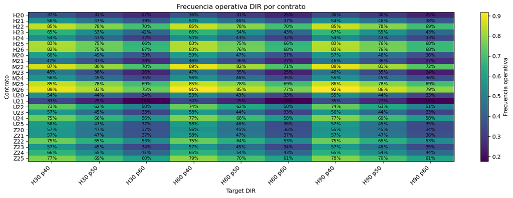

```python
# Celda 5 — Heatmap frecuencia operativa por contrato
# ============================================================

plot_data = contract_signal_pivot.copy()

fig, ax = plt.subplots(figsize=(14, 5))

im = ax.imshow(plot_data.values, aspect="auto")

ax.set_title("Frecuencia operativa DIR por contrato")
ax.set_xlabel("Target DIR")
ax.set_ylabel("Contrato")

ax.set_xticks(np.arange(len(plot_data.columns)))
ax.set_xticklabels(plot_data.columns, rotation=45, ha="right")

ax.set_yticks(np.arange(len(plot_data.index)))
ax.set_yticklabels(plot_data.index)

for i in range(plot_data.shape[0]):
    for j in range(plot_data.shape[1]):
        value = plot_data.iloc[i, j]
        if pd.notna(value):
            ax.text(
                j,
                i,
                f"{value:.0%}",
                ha="center",
                va="center",
                fontsize=8
            )

fig.colorbar(im, ax=ax, label="Frecuencia operativa")

plt.tight_layout()
plt.show()
```

### Celda 6 — Gráfico por contrato para p50

Este gráfico se enfoca en p50, que venimos usando como variante central.

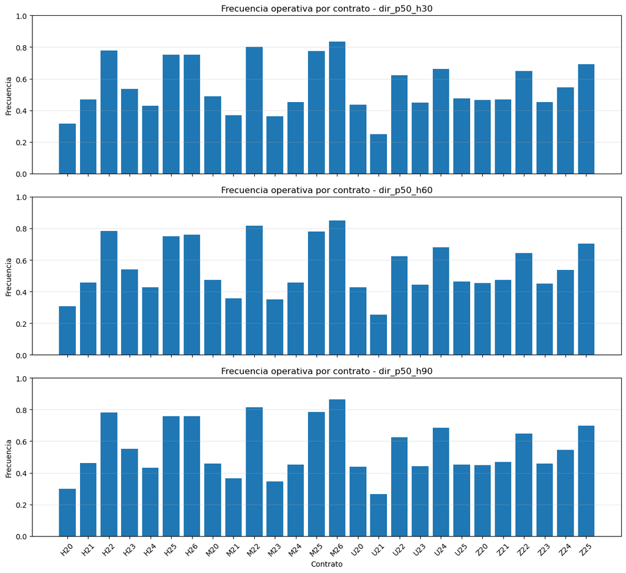

```python
# Celda 6 — Frecuencia operativa por contrato para p50
# Gráfico agrupado: 3 filas x 1 columna
# ============================================================

fig, axes = plt.subplots(
    nrows=3,
    ncols=1,
    figsize=(12, 11),
    sharex=True
)

for ax, target_col in zip(axes, selected_targets_context):
    tmp = df_dir_contract_distribution[
        df_dir_contract_distribution["target"] == target_col
    ].copy()

    tmp = tmp.sort_values("contract")

    ax.bar(
        tmp["contract"].astype(str),
        tmp["signal_ratio"]
    )

    ax.set_title(f"Frecuencia operativa por contrato - {target_col}")
    ax.set_xlabel("")
    ax.set_ylabel("Frecuencia")
    ax.set_ylim(0, 1)
    ax.grid(axis="y", alpha=0.3)

axes[-1].set_xlabel("Contrato")

plt.xticks(rotation=45)
plt.tight_layout()
plt.show()
```

### Celda 7 — Análisis por contract_code

```python
# Celda 7 — Distribución de DIR por contract_code
# ============================================================

df_dir_contract_code_distribution = summarize_dir_by_context(
    df=df_targets_dir,
    target_cols=dir_target_cols,
    group_cols=["contract_code"]
)

print("Distribución de DIR por contract_code")
print("=" * 80)

cols_show = [
    "contract_code",
    "target",
    "horizon",
    "percentile",
    "valid_rows",
    "nan_rows",
    "signal_ratio",
    "no_signal_ratio",
    "long_share_over_signals",
]

print(
    df_dir_contract_code_distribution[cols_show]
    .to_string(index=False, float_format=lambda x: f"{x:.2%}")
)
```

```
Distribución de DIR por contract_code
================================================================================
contract_code      target  horizon  percentile  valid_rows  nan_rows  signal_ratio  no_signal_ratio  long_share_over_signals
            H dir_p40_h30       30          40      265722     12060        66.63%           33.37%                   48.76%
            H dir_p50_h30       30          50      265722     12060        58.09%           41.91%                   48.40%
            H dir_p60_h30       30          60      265722     12060        49.48%           50.52%                   47.96%
            H dir_p40_h60       60          40      253662     24120        66.64%           33.36%                   48.98%
            H dir_p50_h60       60          50      253662     24120        58.06%           41.94%                   48.19%
            H dir_p60_h60       60          60      253662     24120        49.31%           50.69%                   47.33%
            H dir_p40_h90       90          40      241602     36180        66.60%           33.40%                   48.82%
            H dir_p50_h90       90          50      241602     36180        58.39%           41.61%                   48.15%
            H dir_p60_h90       90          60      241602     36180        49.59%           50.41%                   47.23%
            M dir_p40_h30       30          40      243248     11040        64.57%           35.43%                   50.25%
            M dir_p50_h30       30          50      243248     11040        55.18%           44.82%                   49.62%
            M dir_p60_h30       30          60      243248     11040        45.41%           54.59%                   48.80%
            M dir_p40_h60       60          40      232208     22080        64.61%           35.39%                   50.03%
            M dir_p50_h60       60          50      232208     22080        55.00%           45.00%                   49.17%
            M dir_p60_h60       60          60      232208     22080        45.31%           54.69%                   48.35%
            M dir_p40_h90       90          40      221168     33120        64.32%           35.68%                   49.97%
            M dir_p50_h90       90          50      221168     33120        54.92%           45.08%                   49.23%
            M dir_p60_h90       90          60      221168     33120        45.40%           54.60%                   48.25%
            U dir_p40_h30       30          40      233333     10590        58.16%           41.84%                   49.50%
            U dir_p50_h30       30          50      233333     10590        47.88%           52.12%                   48.49%
            U dir_p60_h30       30          60      233333     10590        37.76%           62.24%                   47.18%
            U dir_p40_h60       60          40      222743     21180        58.76%           41.24%                   48.95%
            U dir_p50_h60       60          50      222743     21180        47.93%           52.07%                   47.74%
            U dir_p60_h60       60          60      222743     21180        37.61%           62.39%                   46.39%
            U dir_p40_h90       90          40      212153     31770        58.88%           41.12%                   48.58%
            U dir_p50_h90       90          50      212153     31770        48.24%           51.76%                   47.39%
            U dir_p60_h90       90          60      212153     31770        37.49%           62.51%                   46.06%
            Z dir_p40_h30       30          40      237299     10770        64.87%           35.13%                   50.06%
            Z dir_p50_h30       30          50      237299     10770        54.64%           45.36%                   49.67%
            Z dir_p60_h30       30          60      237299     10770        44.23%           55.77%                   49.21%
            Z dir_p40_h60       60          40      226529     21540        64.92%           35.08%                   50.47%
            Z dir_p50_h60       60          50      226529     21540        54.41%           45.59%                   49.92%
            Z dir_p60_h60       60          60      226529     21540        44.02%           55.98%                   49.10%
            Z dir_p40_h90       90          40      215759     32310        64.84%           35.16%                   50.24%
            Z dir_p50_h90       90          50      215759     32310        54.57%           45.43%                   49.58%
            Z dir_p60_h90       90          60      215759     32310        43.92%           56.08%                   48.67%
```

### Celda 8 — Estabilidad por contract_code

```python
# Celda 8 — Métricas de estabilidad por contract_code
# ============================================================

df_contract_code_stability = (
    df_dir_contract_code_distribution
    .groupby(["target", "horizon", "percentile"], as_index=False)
    .agg(
        signal_mean=("signal_ratio", "mean"),
        signal_std=("signal_ratio", "std"),
        signal_min=("signal_ratio", "min"),
        signal_max=("signal_ratio", "max"),
        signal_range=("signal_ratio", lambda x: x.max() - x.min()),
        long_share_mean=("long_share_over_signals", "mean"),
        long_share_range=("long_share_over_signals", lambda x: x.max() - x.min()),
    )
    .sort_values(["percentile", "horizon"])
    .reset_index(drop=True)
)

print("Estabilidad de DIR por contract_code")
print("=" * 80)
print(
    df_contract_code_stability.to_string(
        index=False,
        float_format=lambda x: f"{x:.2%}"
    )
)
```

```
Estabilidad de DIR por contract_code
================================================================================
     target  horizon  percentile  signal_mean  signal_std  signal_min  signal_max  signal_range  long_share_mean  long_share_range
dir_p40_h30       30          40       63.56%       3.71%      58.16%      66.63%         8.47%           49.64%             1.49%
dir_p40_h60       60          40       63.73%       3.43%      58.76%      66.64%         7.87%           49.61%             1.52%
dir_p40_h90       90          40       63.66%       3.33%      58.88%      66.60%         7.72%           49.40%             1.66%
dir_p50_h30       30          50       53.95%       4.32%      47.88%      58.09%        10.21%           49.05%             1.27%
dir_p50_h60       60          50       53.85%       4.26%      47.93%      58.06%        10.13%           48.75%             2.18%
dir_p50_h90       90          50       54.03%       4.23%      48.24%      58.39%        10.15%           48.59%             2.19%
dir_p60_h30       30          60       44.22%       4.86%      37.76%      49.48%        11.71%           48.29%             2.03%
dir_p60_h60       60          60       44.06%       4.85%      37.61%      49.31%        11.70%           47.79%             2.71%
dir_p60_h90       90          60       44.10%       5.02%      37.49%      49.59%        12.09%           47.55%             2.61%
```

### Celda 9 — Análisis year + regime

Esta celda ayuda a detectar si ciertos años tienen más señales en algunos regímenes específicos.

```python
# Celda 9 — Análisis DIR por year + regime
# ============================================================

df_dir_year_regime_distribution = summarize_dir_by_context(
    df=df_targets_dir,
    target_cols=dir_target_cols,
    group_cols=["year", "regime_name"]
)

print("Distribución de DIR por year + regime")
print("=" * 80)

cols_show = [
    "year",
    "regime_name",
    "target",
    "valid_rows",
    "nan_rows",
    "signal_ratio",
    "no_signal_ratio",
    "long_share_over_signals",
]

print(
    df_dir_year_regime_distribution[cols_show]
    .to_string(index=False, float_format=lambda x: f"{x:.2%}")
)
```

```
Distribución de DIR por year + regime
================================================================================
 year regime_name      target  valid_rows  nan_rows  signal_ratio  no_signal_ratio  long_share_over_signals
 2020     Closing dir_p40_h30         225      6525        54.67%           45.33%                   47.97%
 2020     Closing dir_p50_h30         225      6525        45.33%           54.67%                   49.02%
 2020     Closing dir_p60_h30         225      6525        38.67%           61.33%                   50.57%
 2020     Closing dir_p40_h60           0      6750           NaN              NaN                      NaN
 2020     Closing dir_p50_h60           0      6750           NaN              NaN                      NaN
 2020     Closing dir_p60_h60           0      6750           NaN              NaN                      NaN
 2020     Closing dir_p40_h90           0      6750           NaN              NaN                      NaN
 2020     Closing dir_p50_h90           0      6750           NaN              NaN                      NaN
 2020     Closing dir_p60_h90           0      6750           NaN              NaN                      NaN
 2020     Opening dir_p40_h30       13500         0        45.37%           54.63%                   47.43%
 2020     Opening dir_p50_h30       13500         0        35.46%           64.54%                   45.27%
 2020     Opening dir_p60_h30       13500         0        26.47%           73.53%                   43.21%
```

[output cut: 303 more lines]

### Celda 10 — Heatmap year + regime para p50

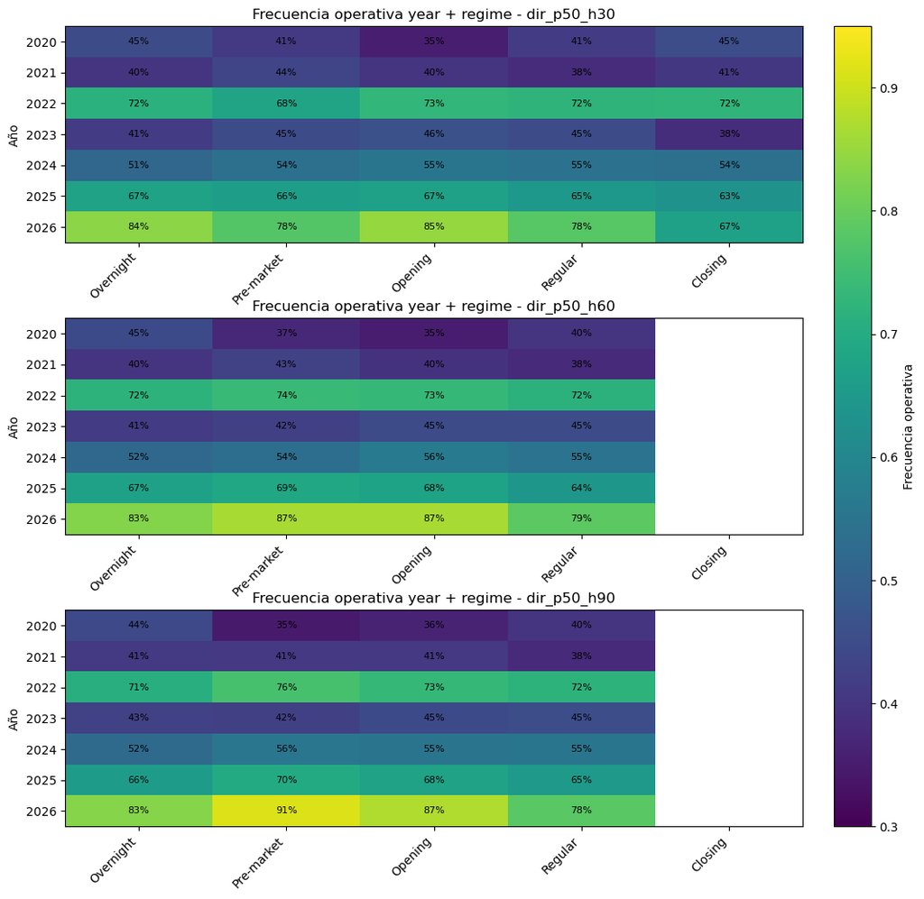

```python
# Celda 10 — Heatmap year + regime para p50
# Gráfico agrupado: 3 filas x 1 columna + colorbar separado
# ============================================================

import matplotlib.pyplot as plt
import numpy as np
import pandas as pd

fig = plt.figure(figsize=(12, 12))

gs = fig.add_gridspec(
    nrows=3,
    ncols=2,
    width_ratios=[20, 1],
    height_ratios=[1, 1, 1],
    wspace=0.08,
    hspace=0.35
)

axes = [fig.add_subplot(gs[i, 0]) for i in range(3)]
cax = fig.add_subplot(gs[:, 1])

vmin = 0.30
vmax = 0.95

last_im = None

for ax, target_col in zip(axes, selected_targets_context):
    tmp = df_dir_year_regime_distribution[
        df_dir_year_regime_distribution["target"] == target_col
    ].copy()

    pivot_tmp = tmp.pivot(
        index="year",
        columns="regime_name",
        values="signal_ratio"
    )

    pivot_tmp = pivot_tmp.reindex(columns=REGIME_ORDER)

    data = np.ma.masked_invalid(pivot_tmp.values)

    last_im = ax.imshow(
        data,
        aspect="auto",
        vmin=vmin,
        vmax=vmax
    )

    ax.set_title(f"Frecuencia operativa year + regime - {target_col}")
    ax.set_ylabel("Año")

    ax.set_yticks(np.arange(len(pivot_tmp.index)))
    ax.set_yticklabels(pivot_tmp.index)

    ax.set_xticks(np.arange(len(pivot_tmp.columns)))
    ax.set_xticklabels(pivot_tmp.columns, rotation=45, ha="right")

    for i in range(pivot_tmp.shape[0]):
        for j in range(pivot_tmp.shape[1]):
            value = pivot_tmp.iloc[i, j]

            if pd.notna(value):
                ax.text(
                    j,
                    i,
                    f"{value:.0%}",
                    ha="center",
                    va="center",
                    fontsize=8
                )

fig.colorbar(
    last_im,
    cax=cax,
    label="Frecuencia operativa"
)

plt.show()
```

### Celda 11 — Análisis contract + regime

Esta celda revisa si ciertos contratos se comportan distinto en ciertos regímenes.

```python
# Celda 11 — Análisis DIR por contract + regime
# ============================================================

df_dir_contract_regime_distribution = summarize_dir_by_context(
    df=df_targets_dir,
    target_cols=dir_target_cols,
    group_cols=["contract", "regime_name"]
)

print("Distribución de DIR por contract + regime")
print("=" * 80)

cols_show = [
    "contract",
    "regime_name",
    "target",
    "valid_rows",
    "nan_rows",
    "signal_ratio",
    "no_signal_ratio",
    "long_share_over_signals",
]

print(
    df_dir_contract_regime_distribution[cols_show]
    .to_string(index=False, float_format=lambda x: f"{x:.2%}")
)
```

```
Distribución de DIR por contract + regime
================================================================================
contract regime_name      target  valid_rows  nan_rows  signal_ratio  no_signal_ratio  long_share_over_signals
     H20     Closing dir_p40_h30          48      1392        33.33%           66.67%                   56.25%
     H20     Closing dir_p50_h30          48      1392        29.17%           70.83%                   57.14%
     H20     Closing dir_p60_h30          48      1392        27.08%           72.92%                   53.85%
     H20     Closing dir_p40_h60           0      1440           NaN              NaN                      NaN
     H20     Closing dir_p50_h60           0      1440           NaN              NaN                      NaN
     H20     Closing dir_p60_h60           0      1440           NaN              NaN                      NaN
     H20     Closing dir_p40_h90           0      1440           NaN              NaN                      NaN
     H20     Closing dir_p50_h90           0      1440           NaN              NaN                      NaN
     H20     Closing dir_p60_h90           0      1440           NaN              NaN                      NaN
     H20     Opening dir_p40_h30        2880         0        29.20%           70.80%                   44.23%
     H20     Opening dir_p50_h30        2880         0        24.34%           75.66%                   46.50%
     H20     Opening dir_p60_h30        2880         0        20.49%           79.51%                   47.63%
     H20     Opening dir_p40_h60        2880         0        31.42%           68.58%                   43.87%
     H20     Opening dir_p50_h60        2880         0        26.04%           73.96%                   45.20%
     H20     Opening dir_p60_h60        2880         0        20.87%           79.13%                   48.75%
     H20     Opening dir_p40_h90        2880         0        30.76%           69.24%                   44.81%
     H20     Opening dir_p50_h90        2880         0        25.62%           74.38%                   46.07%
     H20     Opening dir_p60_h90        2880         0        21.60%           78.40%                   46.14%
     H20   Overnight dir_p40_h30       11520        48        40.26%           59.74%                   47.50%
     H20   Overnight dir_p50_h30       11520        48        34.18%           65.82%                   46.14%
     H20   Overnight dir_p60_h30       11520        48        29.42%           70.58%                   44.50%
     H20   Overnight dir_p40_h60       11520        48        38.87%           61.13%                   46.23%
     H20   Overnight dir_p50_h60       11520        48        32.68%           67.32%                   44.54%
     H20   Overnight dir_p60_h60       11520        48        26.95%           73.05%                   42.61%
     H20   Overnight dir_p40_h90       11520        48        37.73%           62.27%                   43.79%
     H20   Overnight dir_p50_h90       11520        48        31.67%           68.33%                   41.34%
     H20   Overnight dir_p60_h90       11520        48        26.95%           73.05%                   39.74%
     H20  Pre-market dir_p40_h30        2880         0        38.37%           61.63%                   46.97%
     H20  Pre-market dir_p50_h30        2880         0        31.77%           68.23%                   47.87%
     H20  Pre-market dir_p60_h30        2880         0        25.94%           74.06%                   51.54%
     H20  Pre-market dir_p40_h60        2880         0        33.58%           66.42%                   48.81%
     H20  Pre-market dir_p50_h60        2880         0        28.89%           71.11%                   47.12%
     H20  Pre-market dir_p60_h60        2880         0        23.61%           76.39%                   46.76%
     H20  Pre-market dir_p40_h90        2880         0        33.09%           66.91%                   50.16%
     H20  Pre-market dir_p50_h90        2880         0        28.72%           71.28%                   52.24%
     H20  Pre-market dir_p60_h90        2880         0        22.26%           77.74%                   52.89%
     H20     Regular dir_p40_h30       14400         0        36.32%           63.68%                   44.86%
```

[output cut: 1118 more lines]

```
     Z25  Pre-market dir_p40_h60        3660         0        82.35%           17.65%                   42.00%
     Z25  Pre-market dir_p50_h60        3660         0        75.16%           24.84%                   41.51%
     Z25  Pre-market dir_p60_h60        3660         0        64.78%           35.22%                   42.85%
     Z25  Pre-market dir_p40_h90        3660         0        80.00%           20.00%                   45.90%
     Z25  Pre-market dir_p50_h90        3660         0        71.83%           28.17%                   45.80%
     Z25  Pre-market dir_p60_h90        3660         0        63.80%           36.20%                   46.17%
     Z25     Regular dir_p40_h30       18300         0        74.65%           25.35%                   49.73%
     Z25     Regular dir_p50_h30       18300         0        66.80%           33.20%                   49.59%
     Z25     Regular dir_p60_h30       18300         0        58.70%           41.30%                   49.25%
     Z25     Regular dir_p40_h60       16531      1769        75.06%           24.94%                   51.68%
     Z25     Regular dir_p50_h60       16531      1769        67.27%           32.73%                   50.34%
     Z25     Regular dir_p60_h60       16531      1769        59.70%           40.30%                   48.89%
     Z25     Regular dir_p40_h90       14701      3599        76.48%           23.52%                   50.97%
     Z25     Regular dir_p50_h90       14701      3599        69.17%           30.83%                   49.67%
     Z25     Regular dir_p60_h90       14701      3599        60.52%           39.48%                   47.44%
```

### Celda 12 — Heatmap contract + regime para p50

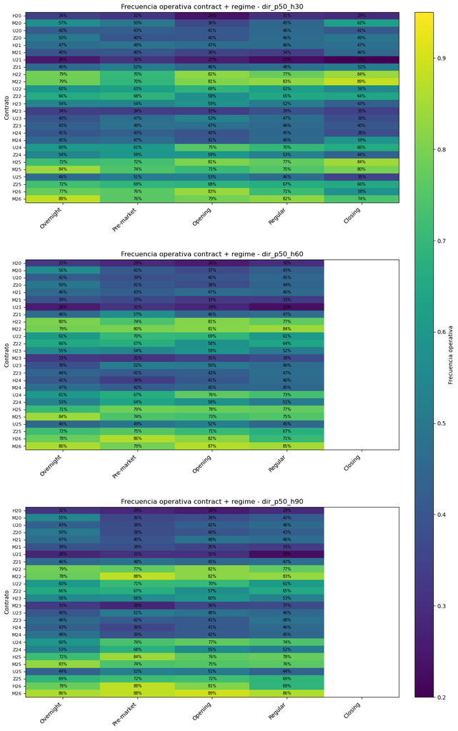

```python
# Celda 12 — Heatmap contract + regime para p50
# Gráfico agrupado: 3 filas x 1 columna + colorbar separado
# ============================================================

import matplotlib.pyplot as plt
import numpy as np
import pandas as pd

def contract_sort_key(contract):
    """
    Ordena contratos del tipo H20, M20, U20, Z20, H21...
    """
    month_order = {"H": 1, "M": 2, "U": 3, "Z": 4}

    contract = str(contract)
    letter = contract[0]
    year = int(contract[1:]) if contract[1:].isdigit() else 999

    return year, month_order.get(letter, 99)


fig = plt.figure(figsize=(13, 22))

gs = fig.add_gridspec(
    nrows=3,
    ncols=2,
    width_ratios=[20, 1],
    height_ratios=[1, 1, 1],
    wspace=0.08,
    hspace=0.30
)

axes = [fig.add_subplot(gs[i, 0]) for i in range(3)]
cax = fig.add_subplot(gs[:, 1])

vmin = 0.20
vmax = 0.95

last_im = None

for ax, target_col in zip(axes, selected_targets_context):
    tmp = df_dir_contract_regime_distribution[
        df_dir_contract_regime_distribution["target"] == target_col
    ].copy()

    pivot_tmp = tmp.pivot(
        index="contract",
        columns="regime_name",
        values="signal_ratio"
    )

    ordered_contracts = sorted(
        pivot_tmp.index.astype(str).tolist(),
        key=contract_sort_key
    )

    pivot_tmp = pivot_tmp.reindex(index=ordered_contracts)
    pivot_tmp = pivot_tmp.reindex(columns=REGIME_ORDER)

    data = np.ma.masked_invalid(pivot_tmp.values)

    last_im = ax.imshow(
        data,
        aspect="auto",
        vmin=vmin,
        vmax=vmax
    )

    ax.set_title(f"Frecuencia operativa contract + regime - {target_col}")
    ax.set_ylabel("Contrato")

    ax.set_yticks(np.arange(len(pivot_tmp.index)))
    ax.set_yticklabels(pivot_tmp.index, fontsize=8)

    ax.set_xticks(np.arange(len(pivot_tmp.columns)))
    ax.set_xticklabels(pivot_tmp.columns, rotation=45, ha="right")

    for i in range(pivot_tmp.shape[0]):
        for j in range(pivot_tmp.shape[1]):
            value = pivot_tmp.iloc[i, j]

            if pd.notna(value):
                ax.text(
                    j,
                    i,
                    f"{value:.0%}",
                    ha="center",
                    va="center",
                    fontsize=7
                )

fig.colorbar(
    last_im,
    cax=cax,
    label="Frecuencia operativa"
)

plt.show()
```